# ISLR - Ch3 - Linear Regression

Darshan Patel

1/19/2019

The following set of problems are from the applied exercises section in ISLR Chapter 3: Linear Regression.

```r
library(MASS)
library(ISLR)
library(tidyverse)
```

## Question 8: This question involves the use of simple linear regression on the `Auto` data set.

1. Use the `lm()` function to perform a linear regression with `mpg` as the response and `horsepower` as the predictor. Use the `summary()` function to print the results. Comment on the output.

```r
df = Auto
model = lm(data = Auto, mpg~horsepower)
summary(model)
```

```
##
## Call:
## lm(formula = mpg ~ horsepower, data = Auto)
##
## Residuals:
##      Min       1Q   Median       3Q      Max
## -13.5710  -3.2592  -0.3435   2.7630  16.9240
##
## Coefficients:
##              Estimate Std. Error t value Pr(>|t|)
## (Intercept) 39.935861   0.717499   55.66   <2e-16 ***
## horsepower  -0.157845   0.006446  -24.49   <2e-16 ***
## ---
## Signif. codes:  0 '***' 0.001 '**' 0.01 '*' 0.05 '.' 0.1 ' ' 1
##
## Residual standard error: 4.906 on 390 degrees of freedom
## Multiple R-squared:  0.6059, Adjusted R-squared:  0.6049
## F-statistic: 599.7 on 1 and 390 DF,  p-value: < 2.2e-16
```

1. Is there a relationship between the predictor and the response?

There is a relationship between the predictor and the response.

2. How strong is the relationship between the predictor and the response?

The relationship between the predictor and the response is strong, with a $p$-value close to $0$.

3. Is the relationship between the predictor and the response positive or negative?

The relationship between the predictor and the response is negative.

4. What is the predicted `mpg` associated with a `horsepower` of $98$? What are the associated $95\%$ confidence and prediction intervals?

The predicted `mpg` associated with a `horsepower` of $98$ is

```r
new_hp = data.frame(horsepower = 98)
predict.lm(model, new_hp)
```

```
##        1
## 24.46708
```

The associated $95\%$ confidence interval is

```r
predict.lm(model, new_hp, interval = "confidence", level = 0.95)
```

```
##        fit      lwr      upr
## 1 24.46708 23.97308 24.96108
```

```r
predict.lm(model, new_hp, interval = "prediction", level = 0.95)
```

```
##        fit     lwr      upr
## 1 24.46708 14.8094 34.12476
```

2. Plot the response and the predictor. Use the `abline()` function to display the least squares regression line.

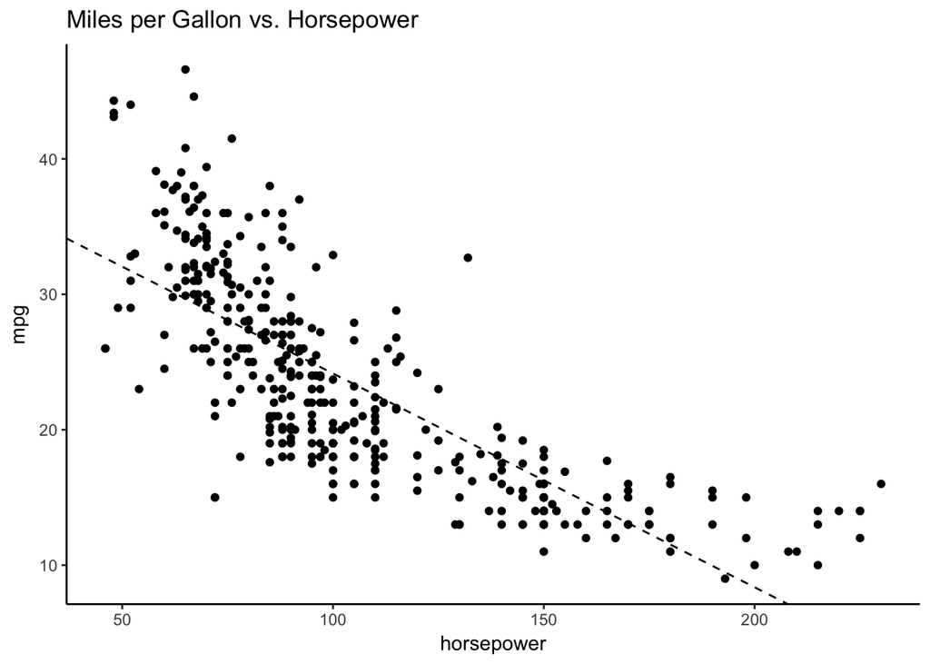

```r
ggplot(df, aes(x = horsepower, y = mpg)) + geom_point() +
  geom_abline(aes(intercept = model$coefficients[1],
                  slope = model$coefficients[2]),
              linetype = 'dashed') +
  ggtitle("Miles per Gallon vs. Horsepower") +
  theme_classic()
```

3. Use the `plot()` function to produce diagnostic plots of the least squares regression fit. Comment on any problems you see with the fit.

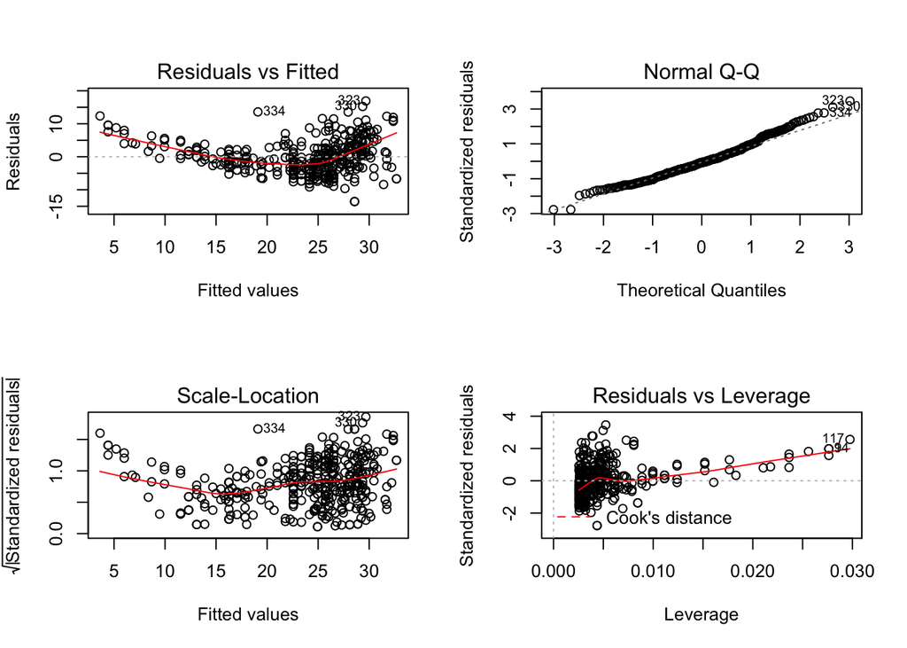

```r
par(mfrow=c(2,2))
plot(model)
```

According to the plots above, the residuals are bigger for values that are at the high end as well as low end. This could mean that the relationship is not linear but rather quadratic. In addition, the residuals vs leverage plot shows that most points don’t have a huge leverage.

## Question 9: This question involves the use of multiple linear regression on the `Auto` data set.

1. Produce a scatterplot matrix which includes all of the variables in the data set.

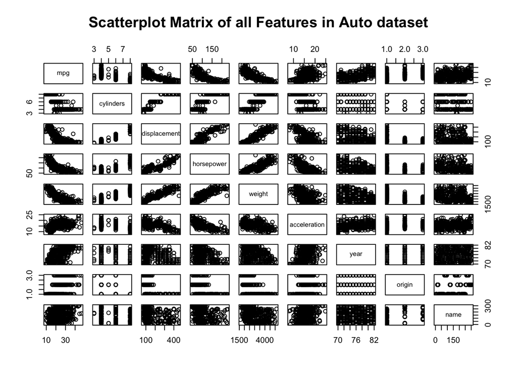

```r
pairs(df, main = "Scatterplot Matrix of all Features in Auto dataset")
```

2. Compute the matrix of correlations between the variables using the function `cor()`. You will need to exclude the `name` variable, which is qualitative.

```r
cor(select(df, which = -name))
```

```
##                     mpg  cylinders displacement horsepower     weight
## mpg           1.0000000 -0.7776175   -0.8051269 -0.7784268 -0.8322442
## cylinders    -0.7776175  1.0000000    0.9508233  0.8429834  0.8975273
## displacement -0.8051269  0.9508233    1.0000000  0.8972570  0.9329944
## horsepower   -0.7784268  0.8429834    0.8972570  1.0000000  0.8645377
## weight       -0.8322442  0.8975273    0.9329944  0.8645377  1.0000000
## acceleration  0.4233285 -0.5046834   -0.5438005 -0.6891955 -0.4168392
## year          0.5805410 -0.3456474   -0.3698552 -0.4163615 -0.3091199
## origin        0.5652088 -0.5689316   -0.6145351 -0.4551715 -0.5850054
##              acceleration       year     origin
## mpg             0.4233285  0.5805410  0.5652088
## cylinders      -0.5046834 -0.3456474 -0.5689316
## displacement   -0.5438005 -0.3698552 -0.6145351
## horsepower     -0.6891955 -0.4163615 -0.4551715
## weight         -0.4168392 -0.3091199 -0.5850054
## acceleration    1.0000000  0.2903161  0.2127458
## year            0.2903161  1.0000000  0.1815277
## origin          0.2127458  0.1815277  1.0000000
```

3. Use the `lm()` function to perform a multiple linear regression with `mpg` as the response and all other variables except `name` as the predictors. Use the `summary()` function to print the results. Comment on the output.

```r
model = lm(data = df, mpg ~ cylinders + displacement + horsepower +
             weight + acceleration + year + origin)
summary(model)
```

```
##
## Call:
## lm(formula = mpg ~ cylinders + displacement + horsepower + weight +
##     acceleration + year + origin, data = df)
##
## Residuals:
##     Min      1Q  Median      3Q     Max
## -9.5903 -2.1565 -0.1169  1.8690 13.0604
##
## Coefficients:
##                Estimate Std. Error t value Pr(>|t|)
## (Intercept)  -17.218435   4.644294  -3.707  0.00024 ***
## cylinders     -0.493376   0.323282  -1.526  0.12780
## displacement   0.019896   0.007515   2.647  0.00844 **
## horsepower    -0.016951   0.013787  -1.230  0.21963
## weight        -0.006474   0.000652  -9.929  < 2e-16 ***
## acceleration   0.080576   0.098845   0.815  0.41548
## year           0.750773   0.050973  14.729  < 2e-16 ***
## origin         1.426141   0.278136   5.127 4.67e-07 ***
## ---
## Signif. codes:  0 '***' 0.001 '**' 0.01 '*' 0.05 '.' 0.1 ' ' 1
##
## Residual standard error: 3.328 on 384 degrees of freedom
## Multiple R-squared:  0.8215, Adjusted R-squared:  0.8182
## F-statistic: 252.4 on 7 and 384 DF,  p-value: < 2.2e-16
```

1. Is there a relationship between the predictors and the response?

Some predictors have a relationship with the response while some dont.

2. Which predictors appear to have a statistically significant relationship to the response?

Predictors `displacement`, `weight`, `year` and `origin` are statistically significant. The predictors that have high $p$-values, such as `cylinders`, `horsepower` and `acceleration` don’t show a relationship with `mpg` and so are not statistically significant with the response.

3. What does the coefficient for the `year` variable suggest?

The coefficient for `year` is $0.75$; this suggests that later years have a greater impact on the `mpg` than earlier years.